# Group_Project_Final

### CHURN ANALYSIS

#### Group 6

Adaobi Nwachukwu : 0808547

Asif Ahmed : 0823547

Ayushi Patel: 0804322

Jaykumar Prakashkumar Prajapati: 0802302

Pavni Bhatt: 0822290

### 1. Importing Libraries

```python
#importing all the required libraries
from sklearn.metrics import recall_score,precision_score,accuracy_score, confusion_matrix,classification_report
from sklearn.model_selection import train_test_split
from sklearn.linear_model import LogisticRegression
from sklearn.tree import DecisionTreeClassifier
warnings.filterwarnings('ignore')
from imblearn.over_sampling import SMOTE
from sklearn import preprocessing
import matplotlib.pyplot as plt
from sklearn import tree
from rfpimp import *
import seaborn as sns
import pandas as pd
import numpy as np
```

### 2. Importing Dataset

```python
df = pd.read_csv("E-Commerce Churn Data.csv")
df.head(10)
```

|  | CustomerID | Churn | Tenure | PreferredLoginDevice | CityTier | WarehouseToHome | PreferredPaymentMode | Gender | HourSpendOnApp | NumberOfDeviceRegistered | PreferedOrderCat | SatisfactionScore | MaritalStatus | NumberOfAddress | Complain | OrderAmountHikeFromlastYear | CouponUsed | OrderCount | DaySinceLastOrder | CashbackAmount |
| --- | --- | --- | --- | --- | --- | --- | --- | --- | --- | --- | --- | --- | --- | --- | --- | --- | --- | --- | --- | --- |
| 0 | 50001 | 1 | 4.0 | Mobile Phone | 3 | 6.0 | Debit Card | Female | 3.0 | 3 | Laptop & Accessory | 2 | Single | 9 | 1 | 11.0 | 1.0 | 1.0 | 5.0 | 160 |
| 1 | 50002 | 1 | NaN | Phone | 1 | 8.0 | UPI | Male | 3.0 | 4 | Mobile | 3 | Single | 7 | 1 | 15.0 | 0.0 | 1.0 | 0.0 | 121 |
| 2 | 50003 | 1 | NaN | Phone | 1 | 30.0 | Debit Card | Male | 2.0 | 4 | Mobile | 3 | Single | 6 | 1 | 14.0 | 0.0 | 1.0 | 3.0 | 120 |
| 3 | 50004 | 1 | 0.0 | Phone | 3 | 15.0 | Debit Card | Male | 2.0 | 4 | Laptop & Accessory | 5 | Single | 8 | 0 | 23.0 | 0.0 | 1.0 | 3.0 | 134 |
| 4 | 50005 | 1 | 0.0 | Phone | 1 | 12.0 | CC | Male | NaN | 3 | Mobile | 5 | Single | 3 | 0 | 11.0 | 1.0 | 1.0 | 3.0 | 130 |
| 5 | 50006 | 1 | 0.0 | Computer | 1 | 22.0 | Debit Card | Female | 3.0 | 5 | Mobile Phone | 5 | Single | 2 | 1 | 22.0 | 4.0 | 6.0 | 7.0 | 139 |
| 6 | 50007 | 1 | NaN | Phone | 3 | 11.0 | Cash on Delivery | Male | 2.0 | 3 | Laptop & Accessory | 2 | Divorced | 4 | 0 | 14.0 | 0.0 | 1.0 | 0.0 | 121 |
| 7 | 50008 | 1 | NaN | Phone | 1 | 6.0 | CC | Male | 3.0 | 3 | Mobile | 2 | Divorced | 3 | 1 | 16.0 | 2.0 | 2.0 | 0.0 | 123 |
| 8 | 50009 | 1 | 13.0 | Phone | 3 | 9.0 | E wallet | Male | NaN | 4 | Mobile | 3 | Divorced | 2 | 1 | 14.0 | 0.0 | 1.0 | 2.0 | 127 |
| 9 | 50010 | 1 | NaN | Phone | 1 | 31.0 | Debit Card | Male | 2.0 | 5 | Mobile | 3 | Single | 2 | 0 | 12.0 | 1.0 | 1.0 | 1.0 | 123 |

```python
# df.shape (5630,20)
#df.info()
#df.describe()
# df.nunique()
```

### 3. Data Preprocessing

```
[Text(0.5, 1.0, 'Box Plot of Customer Transaction and Engagement Metrics')]
```

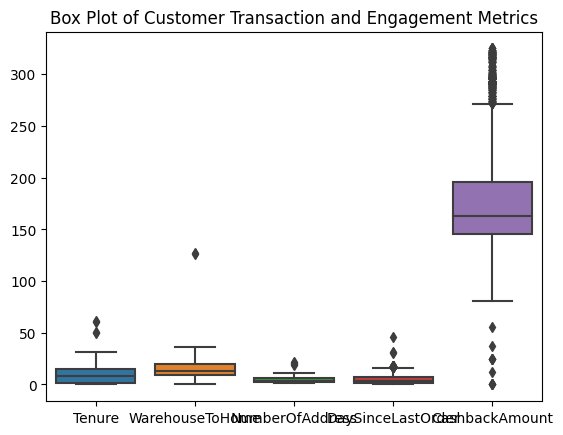

```python
# df.isna().sum()

df = df.fillna(0)
df.loc[df['PreferredPaymentMode'] == 'Cash on Delivery','PreferredPaymentMode'] = 'COD'
df.loc[df['PreferredPaymentMode'] == 'CC','PreferredPaymentMode'] = 'Credit Card'
df.loc[df['PreferredLoginDevice'] == 'Phone','PreferredLoginDevice'] = 'Mobile Phone'
df.loc[df['PreferredLoginDevice'] == 'Mobile','PreferredLoginDevice'] = 'Mobile Phone'
df.loc[df['PreferedOrderCat'] == 'Phone','PreferedOrderCat'] = 'Mobile Phone'
df.loc[df['PreferedOrderCat'] == 'Mobile','PreferedOrderCat'] = 'Mobile Phone'

ncol = ['Tenure','WarehouseToHome','NumberOfAddress','DaySinceLastOrder','CashbackAmount']
sns.boxplot(data=df[ncol]).set(title="Box Plot of Customer Transaction and Engagement Metrics")
```

### 4. Data Analysis

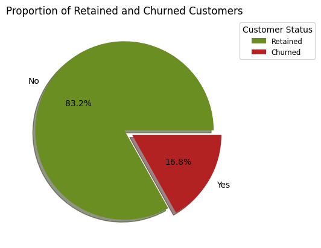

```python
### Graph 1
colors = ['olivedrab', 'firebrick']
plt.pie(df['Churn'].value_counts(),
        labels=["No","Yes"],
        explode=[0, 0.1],
        colors=colors,
        autopct='%1.1f%%',
        shadow=True)
plt.title("Proportion of Retained and Churned Customers")
legend_labels = ['Retained', 'Churned']
legend = plt.legend(legend_labels, title="Customer Status", loc="upper left",fontsize='small', bbox_to_anchor=(1.0, 1.0))
plt.show()
```

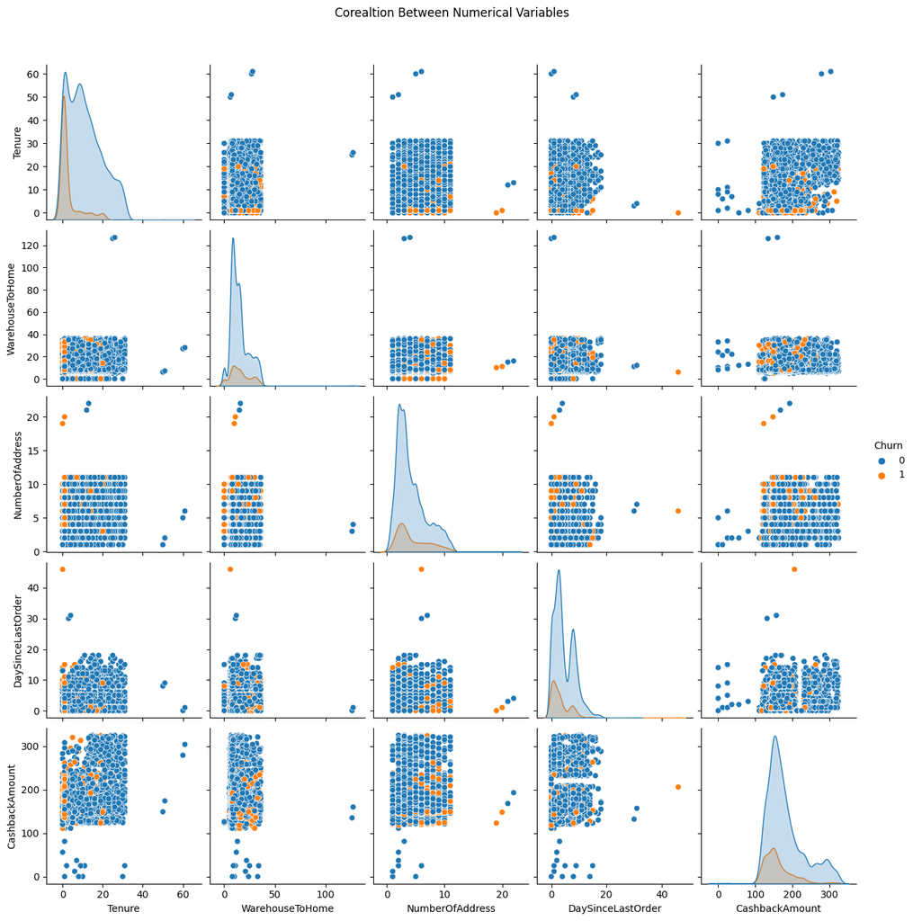

```python
col = ['Tenure','WarehouseToHome','NumberOfAddress','DaySinceLastOrder','CashbackAmount','Churn']
df1 = df[col]
sns.pairplot(data = df1, hue='Churn')
plt.suptitle("Corealtion Between Numerical Variables",y=1.05)
plt.show()
```

**Description** : Above graph shows the correlation among different features within the data and it will help us in giving a direction to our analysis.

```python
#Dividing data
churnData = df[df["Churn"]==1]
noChurnData = df[df["Churn"]==0]
```

```python
churnData.head()
```

|  | CustomerID | Churn | Tenure | PreferredLoginDevice | CityTier | WarehouseToHome | PreferredPaymentMode | Gender | HourSpendOnApp | NumberOfDeviceRegistered | PreferedOrderCat | SatisfactionScore | MaritalStatus | NumberOfAddress | Complain | OrderAmountHikeFromlastYear | CouponUsed | OrderCount | DaySinceLastOrder | CashbackAmount |
| --- | --- | --- | --- | --- | --- | --- | --- | --- | --- | --- | --- | --- | --- | --- | --- | --- | --- | --- | --- | --- |
| 0 | 50001 | 1 | 4.0 | Mobile Phone | 3 | 6.0 | Debit Card | Female | 3.0 | 3 | Laptop & Accessory | 2 | Single | 9 | 1 | 11.0 | 1.0 | 1.0 | 5.0 | 160 |
| 1 | 50002 | 1 | 0.0 | Mobile Phone | 1 | 8.0 | UPI | Male | 3.0 | 4 | Mobile Phone | 3 | Single | 7 | 1 | 15.0 | 0.0 | 1.0 | 0.0 | 121 |
| 2 | 50003 | 1 | 0.0 | Mobile Phone | 1 | 30.0 | Debit Card | Male | 2.0 | 4 | Mobile Phone | 3 | Single | 6 | 1 | 14.0 | 0.0 | 1.0 | 3.0 | 120 |
| 3 | 50004 | 1 | 0.0 | Mobile Phone | 3 | 15.0 | Debit Card | Male | 2.0 | 4 | Laptop & Accessory | 5 | Single | 8 | 0 | 23.0 | 0.0 | 1.0 | 3.0 | 134 |
| 4 | 50005 | 1 | 0.0 | Mobile Phone | 1 | 12.0 | Credit Card | Male | 0.0 | 3 | Mobile Phone | 5 | Single | 3 | 0 | 11.0 | 1.0 | 1.0 | 3.0 | 130 |

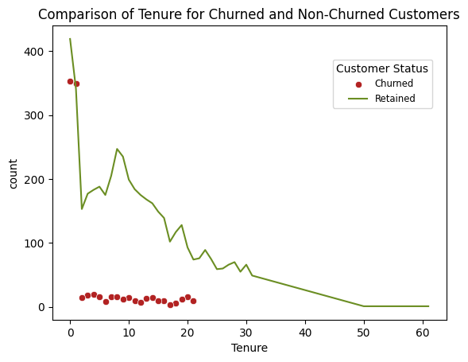

```python
# Plotting graph 1
X = pd.DataFrame(churnData['Tenure'].value_counts().reset_index())

sns.scatterplot(X, x="Tenure",y='count', color="firebrick")
y = pd.DataFrame(noChurnData['Tenure'].value_counts().reset_index())
sns.lineplot(y, x="Tenure",y='count', color = "olivedrab")
plt.title("Comparison of Tenure for Churned and Non-Churned Customers")
plt.legend(['Churned','Retained'], title="Customer Status", loc="upper left",fontsize='small', bbox_to_anchor=(0.70, 0.9))
plt.show()
```

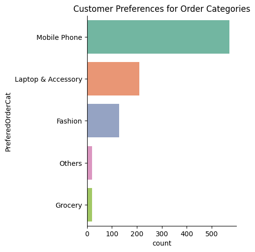

```python
#Graph 2
sns.catplot(data=churnData, y="PreferedOrderCat", kind="count",palette=sns.color_palette("Set2"), order=churnData["PreferedOrderCat"].value_counts().index)
plt.title("Customer Preferences for Order Categories")
plt.show()
```

**Description**: From the above graph, it clearly highlights that Customers with **Mobile Phone** as a perferred order category churns the most, followed by **Laptop & Accessory**

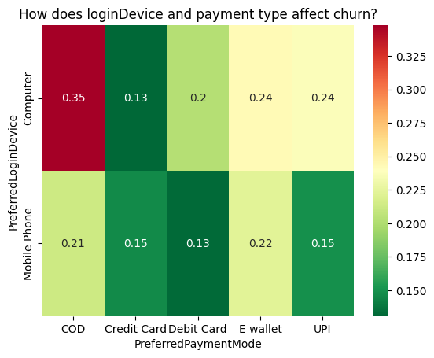

```python
#Graph 3
result = pd.pivot_table(data=df, index='PreferredLoginDevice', columns='PreferredPaymentMode',values='Churn')
sns.heatmap(result, annot=True, cmap = 'RdYlGn_r').set_title('How does loginDevice and payment type affect churn?')
plt.show()
```

**Description** : From the above graph, we can see that customers with **Computer** as Preferred login device and **Cash on Delivery** as their preferred mode of payment, churn the most as compared to other combinations of Login devices and payment mode.

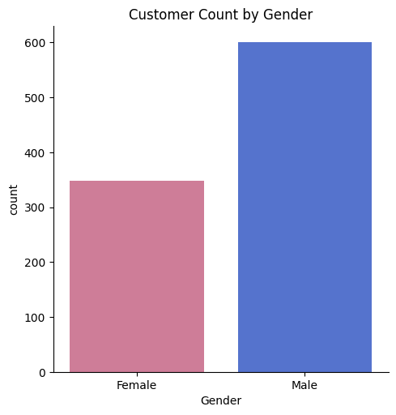

```python
#Graph 4
sns.catplot(data=churnData, x="Gender", kind="count", palette=sns.color_palette(['palevioletred', 'royalblue']))
plt.title('Customer Count by Gender')
plt.show()
```

**Description**: Based on Gender, **Male** customers churn the most as compared to Female customers

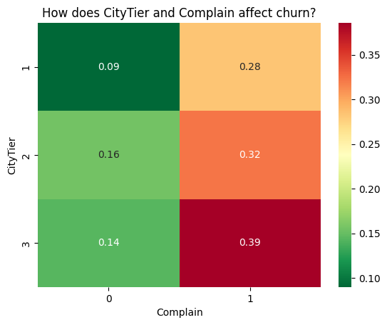

```python
#Graph 5
result = pd.pivot_table(data=df, index='CityTier', columns='Complain',values='Churn')
sns.heatmap(result, annot=True, cmap = 'RdYlGn_r').set_title('How does CityTier and Complain affect churn?')
plt.show()
```

### 5. Model Creation

```python
# Encoding Categorical features
cat_features = df.select_dtypes(['object'])
#cat_features.head()
le = preprocessing.LabelEncoder()
df_cat = cat_features.apply(le.fit_transform)
#df_cat.head()
df1 = df.select_dtypes(['int','float'])

dfa = pd.merge(df1, df_cat, left_index=True, right_index=True)
dfa.head(5)
```

|  | CustomerID | Churn | Tenure | CityTier | WarehouseToHome | HourSpendOnApp | NumberOfDeviceRegistered | SatisfactionScore | NumberOfAddress | Complain | OrderAmountHikeFromlastYear | CouponUsed | OrderCount | DaySinceLastOrder | CashbackAmount | PreferredLoginDevice | PreferredPaymentMode | Gender | PreferedOrderCat | MaritalStatus |
| --- | --- | --- | --- | --- | --- | --- | --- | --- | --- | --- | --- | --- | --- | --- | --- | --- | --- | --- | --- | --- |
| 0 | 50001 | 1 | 4.0 | 3 | 6.0 | 3.0 | 3 | 2 | 9 | 1 | 11.0 | 1.0 | 1.0 | 5.0 | 160 | 1 | 2 | 0 | 2 | 2 |
| 1 | 50002 | 1 | 0.0 | 1 | 8.0 | 3.0 | 4 | 3 | 7 | 1 | 15.0 | 0.0 | 1.0 | 0.0 | 121 | 1 | 4 | 1 | 3 | 2 |
| 2 | 50003 | 1 | 0.0 | 1 | 30.0 | 2.0 | 4 | 3 | 6 | 1 | 14.0 | 0.0 | 1.0 | 3.0 | 120 | 1 | 2 | 1 | 3 | 2 |
| 3 | 50004 | 1 | 0.0 | 3 | 15.0 | 2.0 | 4 | 5 | 8 | 0 | 23.0 | 0.0 | 1.0 | 3.0 | 134 | 1 | 2 | 1 | 2 | 2 |
| 4 | 50005 | 1 | 0.0 | 1 | 12.0 | 0.0 | 3 | 5 | 3 | 0 | 11.0 | 1.0 | 1.0 | 3.0 | 130 | 1 | 1 | 1 | 3 | 2 |

```python
#Splitting data
dfa = dfa.drop(['CustomerID'],axis=1)
X = dfa.drop(['Churn'],axis=1)
y = dfa['Churn']
X_train, X_test, y_train, y_test = train_test_split(X, y, test_size=0.20, random_state=56)

# Oversampling so that model could be train on enough churn samples
oversample = SMOTE(k_neighbors=5)
X_smote, y_smote = oversample.fit_resample(X_train, y_train)
X_train, y_train = X_smote, y_smote
# y_train.value_counts() (Chrun: 0 - 3743, 1 - 3743)
```

```
Accuracy:  0.92
```

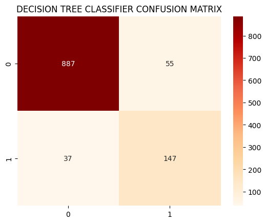

```python
# DECISION TREE
clf = DecisionTreeClassifier(min_samples_split =2)
clf.fit(X_train,y_train)
print("Accuracy: ", f"{clf.score(X_test,y_test):.2f}")
preds = clf.predict(X_test)

cf_matrix = confusion_matrix(y_test, preds)
sns.heatmap(cf_matrix , annot=True,fmt = "d", cmap='OrRd')
plt.title("DECISION TREE CLASSIFIER CONFUSION MATRIX")
plt.show()
```

```python
#Decision Tree Model Summary
print(classification_report(y_test, preds))
```

```
              precision    recall  f1-score   support

           0       0.96      0.94      0.95       942
           1       0.73      0.80      0.76       184

    accuracy                           0.92      1126
   macro avg       0.84      0.87      0.86      1126
weighted avg       0.92      0.92      0.92      1126
```

```
Accuracy:  0.75
```

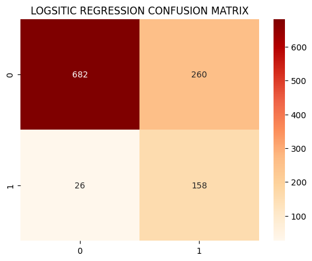

```python
#Logistic Regression
clf1 = LogisticRegression(random_state=77)
clf1.fit(X_train,y_train)
print("Accuracy: ", f"{clf1.score(X_test,y_test):.2f}")
pred1 = clf1.predict(X_test)

cf_matrix1 = confusion_matrix(y_test, pred1)
sns.heatmap(cf_matrix1 , annot=True,fmt = "d", cmap='OrRd')
plt.title("LOGSITIC REGRESSION CONFUSION MATRIX")
plt.show()
```

```python
#Logisitic Regression Model Summary
print(classification_report(y_test, pred1))
```

```
              precision    recall  f1-score   support

           0       0.96      0.72      0.83       942
           1       0.38      0.86      0.52       184

    accuracy                           0.75      1126
   macro avg       0.67      0.79      0.68      1126
weighted avg       0.87      0.75      0.78      1126
```

### 6. Conclusion

Based on the above analysis, here are our findings:

**Customers churn at Early stages** : It can be clearly state that people or the customer churned out the most when they are at their intial stages of the tenure. In other words, the rate at which customers discontinue using a product or service, is most pronounced during the early phases of their relationship with a company. It is very important for businesses to focus on retaining customers during this critical period to build long-term relationships and reduce churn.

**Mobile as a preferred order category among churn customers**: Among customers who have preferences for specific product categories when making orders, those who prefer mobile phones exhibit the highest churn rate, followed by those who prefer laptops and accessories. This could be due to factors such as frequent updates in mobile technology, competitive pricing, and the desire for the latest models, which may lead customers to switch brands or providers more often. It is important to understand the unique dynamics of customer churn in specific product categories and to retain customers.

**Specific combination of 'Computer' (Preferred login devices) and 'Cash on Delivery' (mode of payment) has the highest churn rate**: Among various combinations of customer preferences for login devices and payment modes, this specific combination experiences the highest churn rate. Addressing the challenges associated with this combination of login devices and payment modes can help reduce churn and improve customer retention.

**Male customers churn the most as compared to Female customers**: Males exhibit a higher churn rate compared to females as males may have different buying patterns or brand loyalty. On the flip side,females exhibit lower churn rates, this could involve factors such as brand loyalty or their engagement. Addressing gender-based churn disparities can be crucial for businesses to retain their customer base and tailor their marketing efforts effectively.

### 7. References

https://medium.com/@uqba2199/customer-churn-prediction-using-machine-learning-e36036f6aafa

https://365datascience.com/tutorials/python-tutorials/how-to-build-a-customer-churn-prediction-model-in-python/

https://medium.com/@lucapetriconi/churn-modeling-a-detailed-step-by-step-guide-in-python-1e96d51c7523 https://matplotlib.org/stable/gallery/color/named_colors.html